# Statistical Rethinking: Chapter 5

Simon Thornewill von Essen

2024-03-26

We can learn about the spurious association between divorce and waffle house concentration in a state.

```r
data("WaffleDivorce")
d = WaffleDivorce

d$D = standardize(d$Divorce)
d$M = standardize(d$Marriage)
d$A = standardize(d$MedianAgeMarriage)

m5.1 = quap(
  alist(
    D ~ dnorm(mu_i, sigma),
    mu_i <- a + bA*A,
    a ~ dnorm(0, 0.2),
    bA ~ dnorm(0, 0.5),
    sigma ~ dexp(1)
  ),
  data = d
)

m5.2 = quap(
  alist(
    D ~ dnorm(mu_i, sigma),
    mu_i <- a + bM*M,
    a ~ dnorm(0, 0.2),
    bM ~ dnorm(0, 0.5),
    sigma ~ dexp(1)
  ),
  data = d
)
```

We can sample the priors

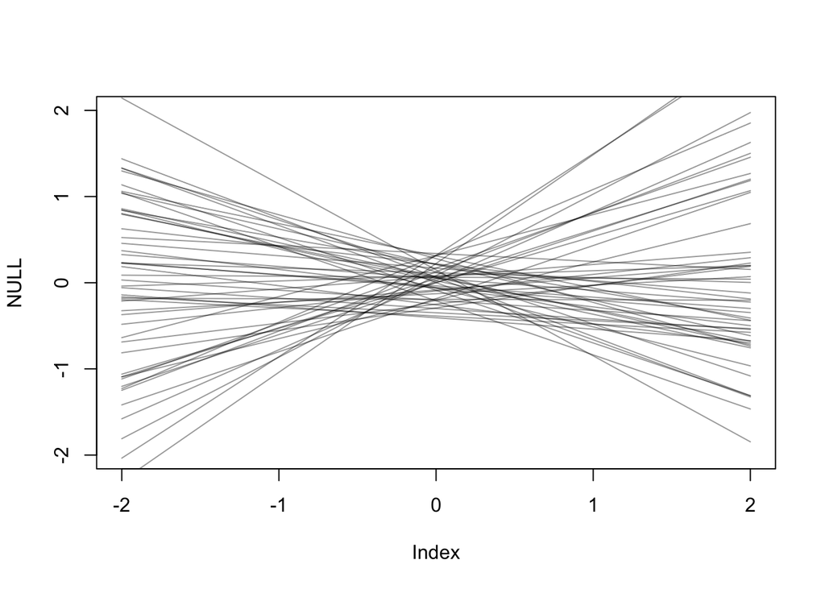

```r
prior = extract.prior(m5.1)
mu = link(m5.1, post=prior, data=list(A=c(-2, 2)))

plot(NULL, xlim=c(-2, 2), ylim=c(-2, 2))
for (i in 1:50)
  lines(c(-2, 2), mu[i,], col=col.alpha("black", 0.4))
```

Looks pretty reasonable…

Now, let’s get some posterior predictions

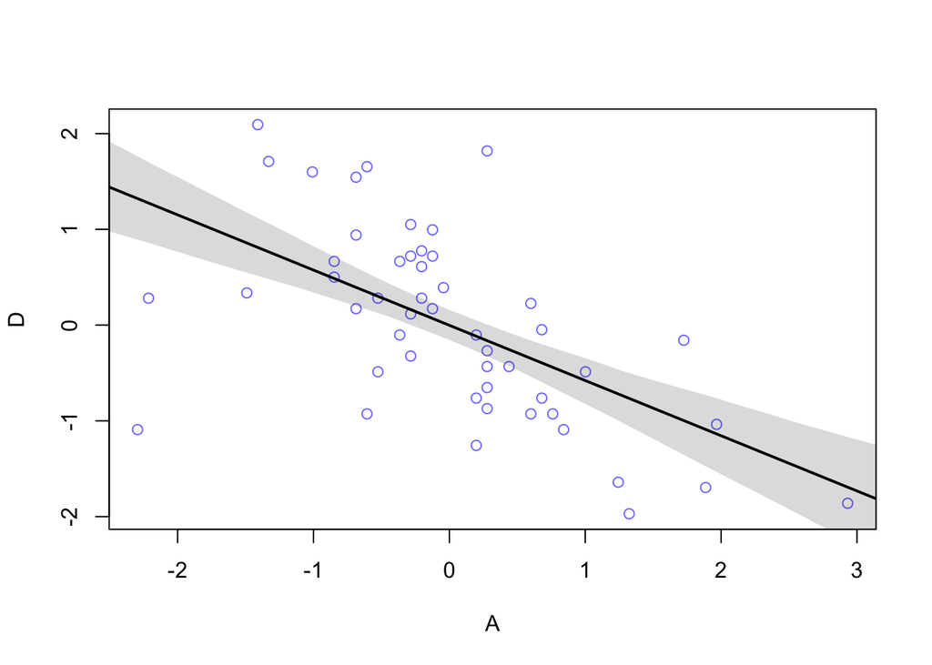

```r
A_seq = seq(from=-3, to=3.2, length.out=30)
mu = link(m5.1, data=list(A=A_seq))
mu.mean = apply(mu, 2, mean)
mu.PI = apply(mu, 2, PI)

#plot it all
plot(D ~ A, data=d, col=rangi2)
lines(A_seq, mu.mean, lwd=2)
shade(mu.PI, A_seq)
```

Now the section talks more about DAGs and we can see that there is an implied conditional independence implied by DAG2 while DAG1 doesn’t.

```r
DMA_dag2 = dagitty('dag{ D <- A -> M}')
impliedConditionalIndependencies(DMA_dag2)
```

```
## D _||_ M | A
```

```r
DMA_dag1 = dagitty('dag{ D <- A -> M -> D}')
impliedConditionalIndependencies(DMA_dag1)
```

We can test this using the following multiple regression:

```r
m5.3 = quap(
  alist(
    D ~ dnorm(mu, sigma),
    mu <- a + bM*M + bA*A,
    a ~ dnorm(0, 0.2),
    bM ~ dnorm(0, 0.5),
    bA ~dnorm(0, 0.5),
    sigma ~ dexp(1)
  ),
  data=d
)

precis(m5.3)
```

```
##                mean         sd       5.5%      94.5%
## a     -1.237307e-06 0.09707328 -0.1551431  0.1551406
## bM    -6.547042e-02 0.15076725 -0.3064256  0.1754848
## bA    -6.134740e-01 0.15097938 -0.8547683 -0.3721798
## sigma  7.850889e-01 0.07783630  0.6606915  0.9094864
```

We can plot the posterior distributions of the coefficients!

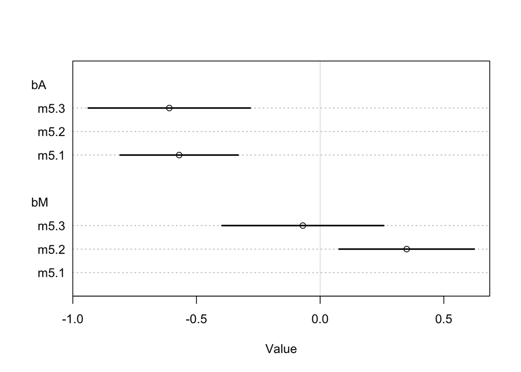

```r
plot(coeftab(m5.1, m5.2, m5.3), par=c("bA", "bM"), prob=0.97)
```

What we see here is that for model 5.2 we can see that there is an effect of marriage on divorce rate but this effect is gone in model 5.3. The reason for this is that when we condition on A then this effect disapears because of the common-cause of A.

i.e. Once we know the median age of marriage for a state then there is little or no additional predictive power in also knowing the rate of marriage in that state.

Next, let’s generate some counterfactuals with some different models

```r
m5.3_A = quap(
  alist(
    ## A -> D <- M
    D ~ dnorm(mu, sigma),
    mu <- a +bM*M + bA*A,
    a ~ dnorm(0, 0.2),
    bM ~ dnorm(0, 0.5),
    bA ~ dnorm(0, 0.5),
    sigma ~ dexp(1),

    ## A -> M
    M ~ dnorm(mu_M, sigma_M),
    mu_M <- aM + bAM*A,
    aM ~ dnorm(0, 0.2),
    bAM ~ dnorm(0, 0.5),
    sigma_M ~ dexp(1)
  ),
  data = d
)

precis(m5.3_A)
```

```
##                  mean         sd       5.5%      94.5%
## a        1.059127e-04 0.09707674 -0.1550415  0.1552533
## bM      -6.523027e-02 0.15077577 -0.3061991  0.1757385
## bA      -6.133658e-01 0.15098679 -0.8546719 -0.3720598
## sigma    7.851255e-01 0.07784536  0.6607135  0.9095374
## aM      -5.848885e-06 0.08684196 -0.1387961  0.1387844
## bAM     -6.947278e-01 0.09571932 -0.8477057 -0.5417498
## sigma_M  6.816800e-01 0.06756602  0.5736964  0.7896635
```

Pretty cool how you can fit two models at the same time.

Next, we want to simulate what happens if we modulate A and see how that effects D and M. We can do this by sampling from the posterior based on this.

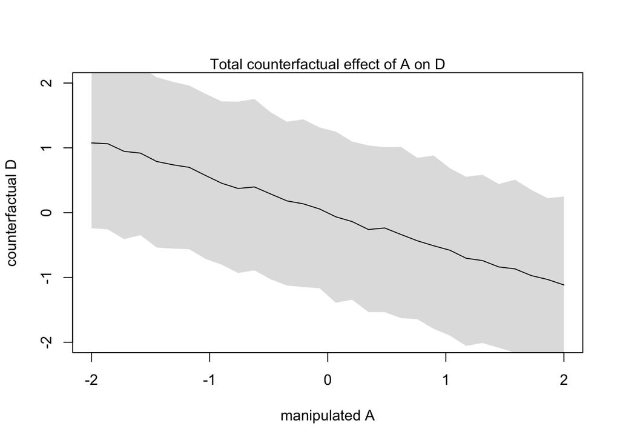

```r
A_seq = seq(from=-2, to=2, length.out=30)

sim_dat = data.frame(A=A_seq)
s = sim(m5.3_A, data=sim_dat, vars=c("M", "D"))

plot(sim_dat$A, colMeans(s$D), ylim=c(-2, 2), type="l",
     xlab="manipulated A", ylab="counterfactual D")
shade(apply(s$D, 2, PI), sim_dat$A)
mtext("Total counterfactual effect of A on D")
```

We can see the total effect in the plot above. We can see that the effect of A on D is pretty big, but this is also the total effect so how much is contributed through the `A -> M -> D` pathway?

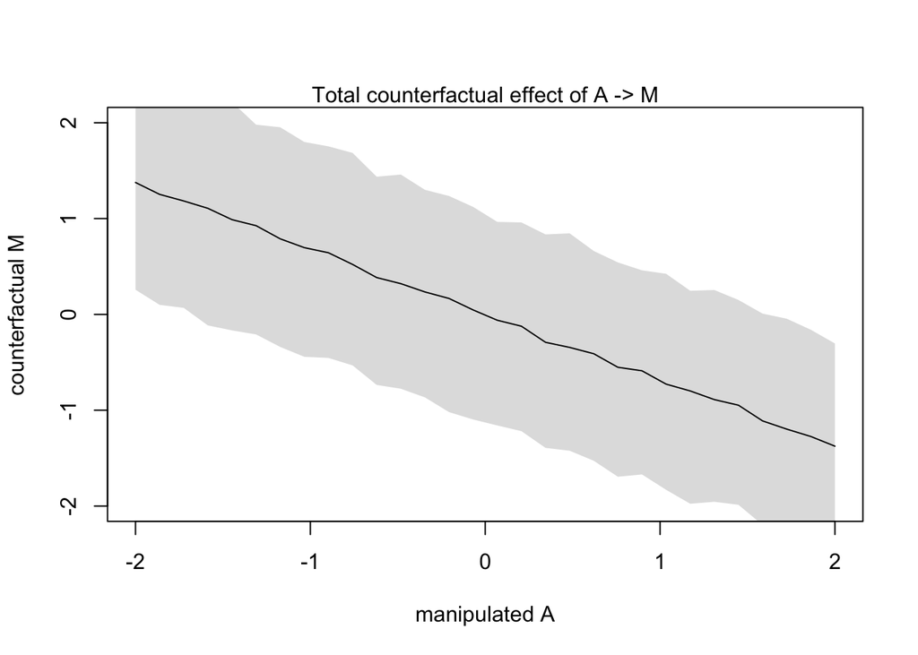

```r
plot(sim_dat$A, colMeans(s$M), ylim=c(-2, 2), type="l",
     xlab="manipulated A", ylab="counterfactual M")
shade(apply(s$M, 2, PI), sim_dat$A)
mtext("Total counterfactual effect of A -> M")
```

We can see some of the partial effect of `A -> M -> D` by just seeing the `A -> M` effect above. This means that if `M -> D` is big then there will be a lot of information transfered in this way as well. So, is this the case?

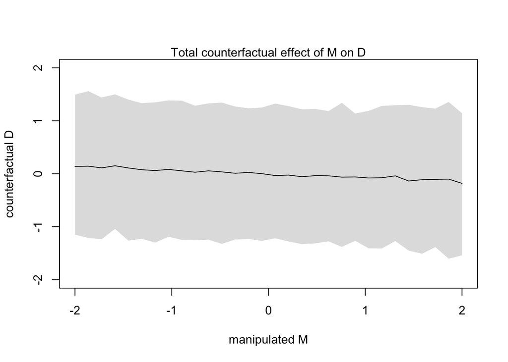

```r
sim_dat = data.frame(M=seq(from=-2, to=2, length.out=30), A=0)
s = sim(m5.3_A, data=sim_dat, vars="D")

plot(sim_dat$M, colMeans(s), ylim=c(-2, 2), type="l",
     xlab="manipulated M", ylab="counterfactual D")
shade(apply(s, 2, PI), sim_dat$M)
mtext("Total counterfactual effect of M on D")
```

We can see that the effect is small so therefore the majority of the effect of `A -> D` comes through the direct `A -> D` pathway rather than through the other `A -> M -> D` one.

Note that it’s not possible for A to have an effect because it was 0 in every case, representing the mean value for A.

So, what did the code do here? Let’s have a look under the hood.

```r
# Using A_seq from before...

# Sample all unobserved variables from posterior distribution
post = extract.samples(m5.3_A)

# For every sample in the posterior, simulate A
M_sim = with(post,
             sapply(1:30,
                    function(i){
                      rnorm(1e3, aM+ bAM*A_seq[i], sigma_M)
                    }))

# We then calculate the distribution of D, using the sampled M and the same A
D_sim = with(post,
             sapply(1:30,
                    function(i){
                      rnorm(1e3, a +
                              bA*A_seq[i] +
                              bM*M_sim[,i],
                            sigma_M)
                    }))
```

Apparently we’ll talk a little about milk and masking now…

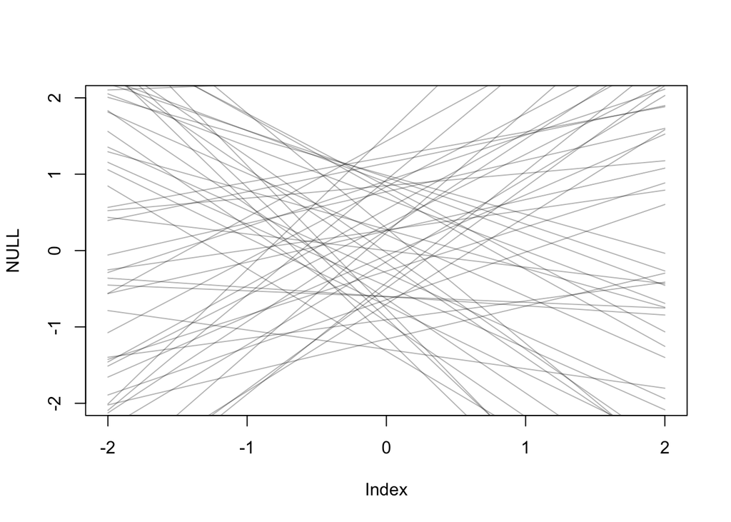

```r
data(milk)
d.m = milk

d.m$K = standardize( d.m$kcal.per.g)
d.m$N = standardize( d.m$neocortex.perc)
d.m$M = standardize( log(d.m$mass))

dcc = d.m[complete.cases(d.m$K, d.m$N, d.m$M),]

m5.5_draft = quap(
  alist(K ~ dnorm( mu, sigma),
        mu <- a + bN*N,
        a ~ dnorm( 0, 1),
        bN ~ dnorm( 0, 1),
        sigma ~ dexp( 1)
        ),
  data=dcc
)

prior = extract.prior( m5.5_draft)
xseq = c(-2,2)
mu = link( m5.5_draft, post=prior, data=list(N=xseq))

plot( NULL, xlim=xseq, ylim=xseq)
for (i in 1:50)
  lines( xseq, mu[i,], col=col.alpha("black",0.3))
```

Well that prior looks like garbage!

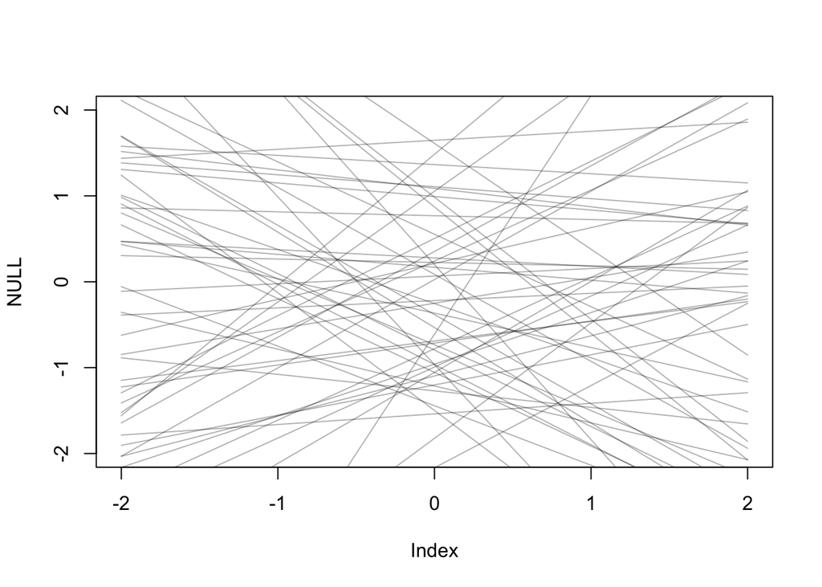

```r
m5.5 = quap(
  alist(K ~ dnorm( mu, sigma),
        mu <- a + bN*N,
        a ~ dnorm( 0, 0.2),
        bN ~ dnorm( 0, 0.5),
        sigma ~ dexp( 1)
        ),
  data=dcc
)

prior = extract.prior( m5.5_draft)
xseq = c(-2,2)
mu = link( m5.5_draft, post=prior, data=list(N=xseq))

plot( NULL, xlim=xseq, ylim=xseq)
for (i in 1:50)
  lines( xseq, mu[i,], col=col.alpha("black",0.3))
```

Let’s check the posterior…

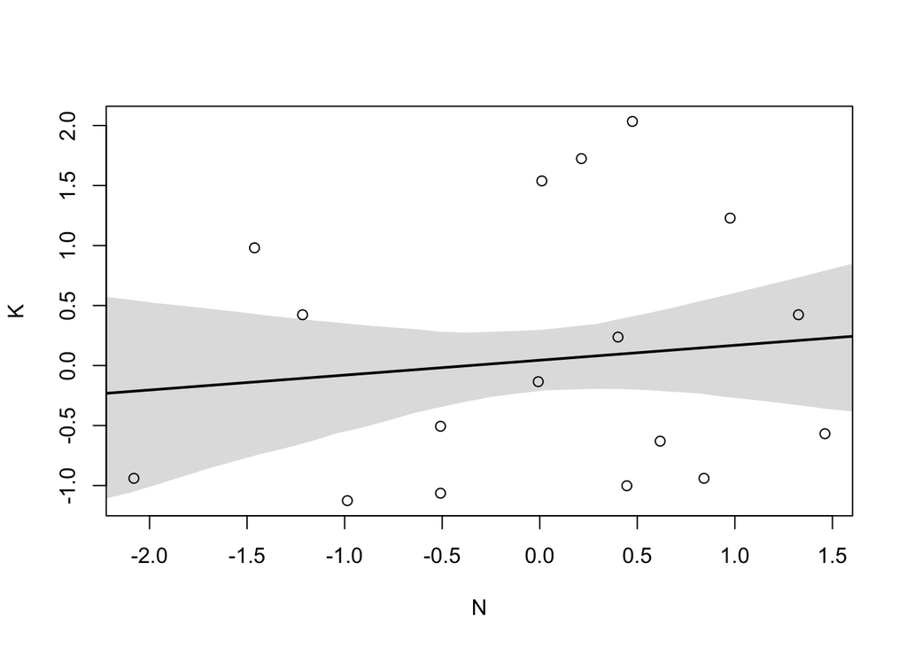

```r
xseq = seq( from=min(dcc$N)-0.15, to=max(dcc$N)+0.15, length.out=30)
mu = link( m5.5, data=list(N=xseq))
mu_mean = apply(mu,2,mean)
mu_PI = apply(mu,2,PI)
plot( K ~ N, data=dcc)
lines( xseq, mu_mean, lwd=2)
shade( mu_PI, xseq)
```

We can now compare this against K and M…

```r
m5.6 = quap(
  alist(
    K ~ dnorm( mu, sigma),
    mu <- a + bM*M,
    a ~ dnorm( 0, 0.2),
    bM ~ dnorm( 0, 0.5),
    sigma ~ dexp( 1)  ),
  data=dcc)

precis(m5.6)
```

```
##              mean        sd       5.5%      94.5%
## a      0.04654116 0.1512800 -0.1952335 0.28831580
## bM    -0.28253578 0.1928817 -0.5907979 0.02572638
## sigma  0.94927871 0.1570612  0.6982645 1.20029291
```

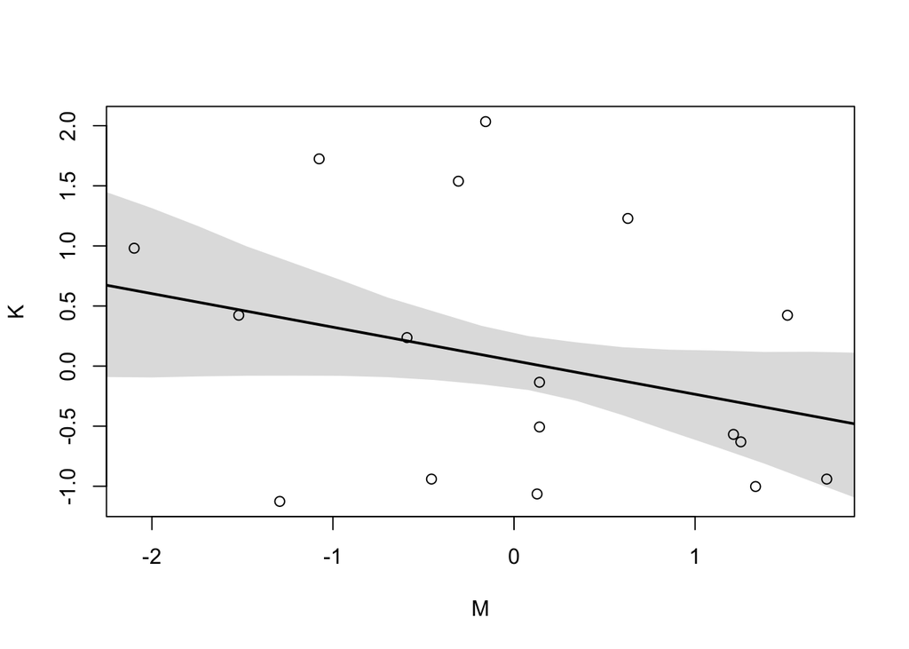

```r
xseq = seq( from=min(dcc$N)-2, to=max(dcc$N)+2, length.out=30)
mu = link( m5.6, data=list(M=xseq))
mu_mean = apply(mu,2,mean)
mu_PI = apply(mu,2,PI)
plot( K ~ M, data=dcc)
lines( xseq, mu_mean, lwd=2)
shade( mu_PI, xseq)
```

You can do a counterfactual analysis as well where you look at the trends while holding the other value constant at 0 but I’ll skip this for now because it’s getting a little repetitive to copy and paste all the time.

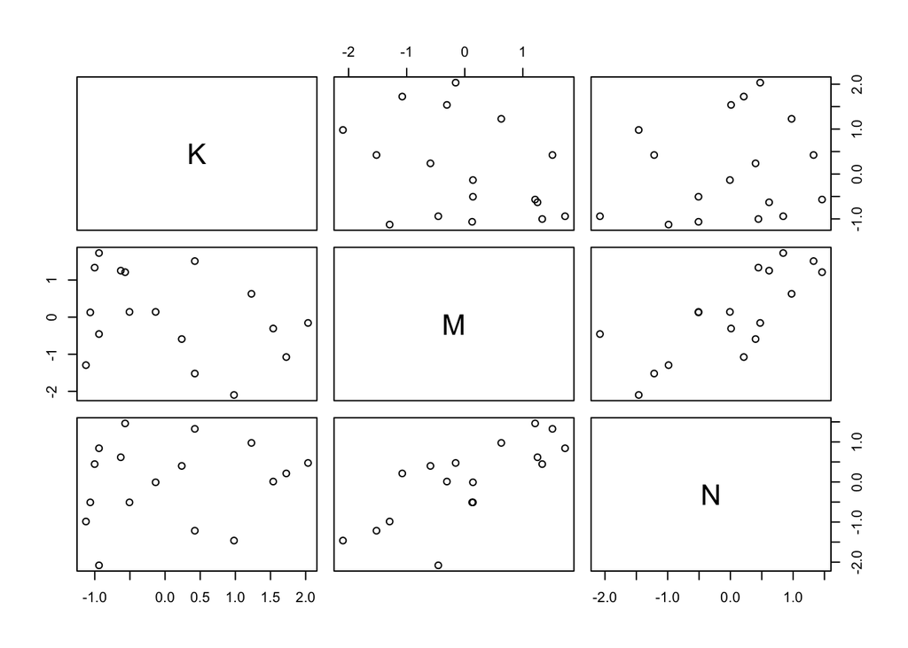

```r
pairs( ~K + M + N, dcc)
```

```r
m5.7 = quap(
  alist(
    K ~ dnorm( mu, sigma),
    mu <- a + bN*N + bM*M,
    a ~ dnorm( 0, 0.2),
    bN ~ dnorm( 0, 0.5),
    bM ~ dnorm( 0, 0.5),
    sigma ~ dexp( 1)  ),
  data=dcc)

precis(m5.7)
```

```
##              mean        sd       5.5%      94.5%
## a      0.06798165 0.1339958 -0.1461696  0.2821329
## bN     0.67515485 0.2482881  0.2783425  1.0719672
## bM    -0.70301783 0.2207781 -1.0558639 -0.3501718
## sigma  0.73798392 0.1324484  0.5263058  0.9496621
```

Using the models above, we can create counter factual plots…

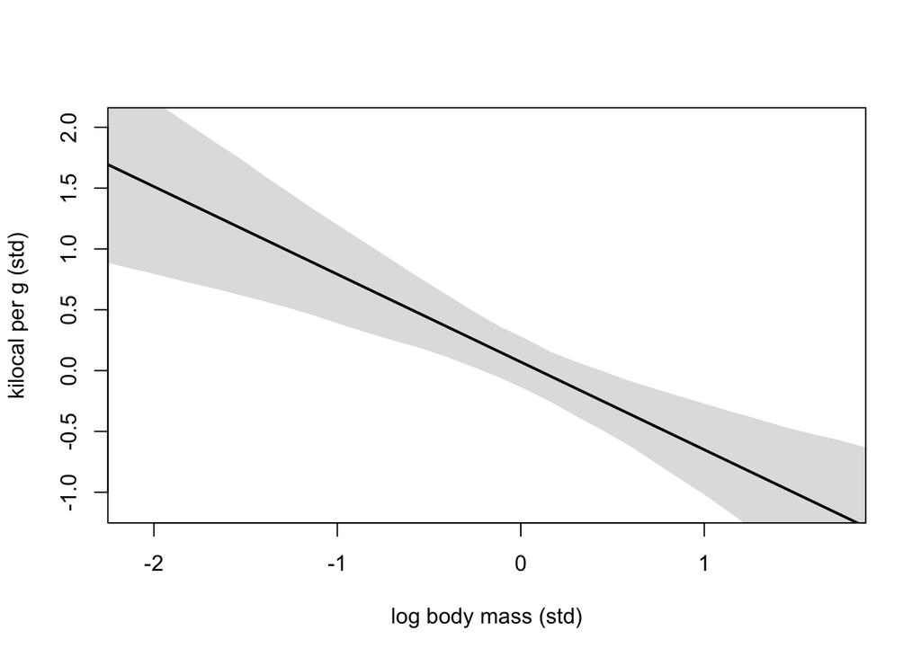

```r
xseq = seq(from=min(dcc$M)-0.15, to=max(dcc$M)+0.15, length.out=30)
mu = link(m5.7, data=data.frame(M=xseq, N=0))
mu_mean = apply(mu,2,mean)
mu_PI = apply(mu,2,PI)
plot(NULL, xlim=range(dcc$M), ylim=range(dcc$K), xlab="log body mass (std)",
     ylab="kilocal per g (std)")
lines( xseq, mu_mean, lwd=2)
shade( mu_PI, xseq)
```

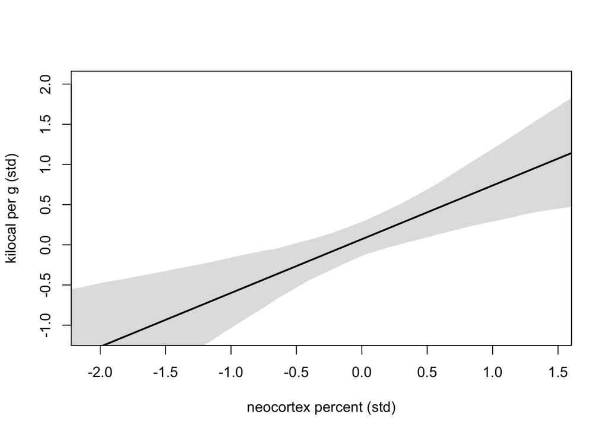

```r
xseq = seq(from=min(dcc$N)-0.15, to=max(dcc$N)+0.15, length.out=30)
mu = link(m5.7, data=data.frame(N=xseq, M=0))
mu_mean = apply(mu,2,mean)
mu_PI = apply(mu,2,PI)
plot( NULL, xlim=range(dcc$N), ylim=range(dcc$K), xlab="neocortex percent (std)",
     ylab="kilocal per g (std)")
lines(xseq, mu_mean, lwd=2)
shade(mu_PI, xseq)
```

Very good…

Now, let’s simulate a masking relationship so that we know what’s going on under the hood.

let’s consider the following DAG; `M -> K <- N` and `M -> N`

```r
## M -> K <- N
## M -> N
n = 100
M = rnorm(n)
N = rnorm(n, M)
K = rnorm(n, N - M)
d_sim = data.frame(K=K, M=M, N=N)
```

We can create the other DAGs analogously…

```r
## M -> K <- N
## N -> M
N = rnorm(n)
M = rnorm(n, N)
K = rnorm(n, N - M)
d_sim2 = data.frame(K=K, M=M, N=N)

## M -> K <- N
## M <- U -> N
U = rnorm(n)
N = rnorm(n, U)
M = rnorm(n, U)
K = rnorm(n, N - M)
d_sim3 = data.frame(K=K, M=M, N=N)
```

For a single dag, we can use `dagitty` to draw all of the equivalent DAGs.

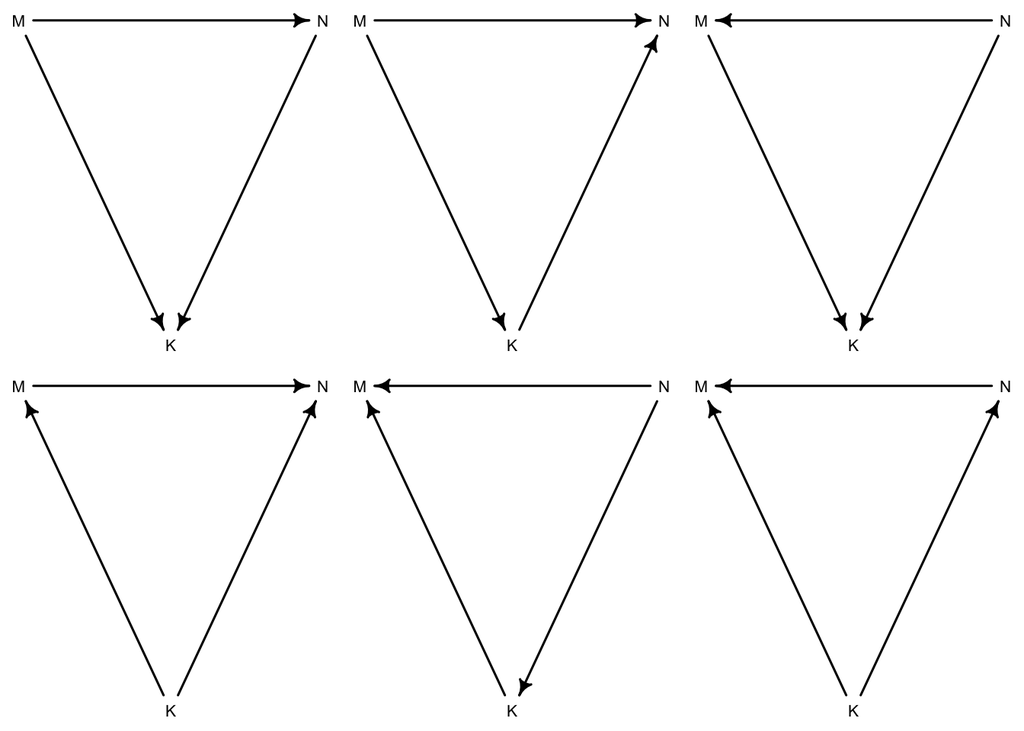

```r
dag5.7 = dagitty( "dag{  M -> K <- N  M -> N}")
coordinates(dag5.7) = list( x=c(M=0,K=1,N=2), y=c(M=0.5,K=1,N=0.5))
MElist = equivalentDAGs(dag5.7)

drawdag(MElist)
```

We can also consider categorical variables, where the labels of a column are discrete and unordered. We can encode this in a regression using dummy/indicator variables. Let’s revisit the `Howell1` dataset…

```r
data(Howell1)
d <- Howell1
d$sex <- ifelse( d$male==1, 2, 1)
```

An important thing to know is not to explicitly take a column of index variables for each categorical variable. Instead, we can use index variables to have two alpha for each gender…

```r
m5.8 = quap(
  alist(
    height ~ dnorm(mu, sigma),
    mu <- a[sex],
    a[sex] ~ dnorm(178, 20),
    sigma ~ dunif(0, 50)
  ),
  data=d
)

precis(m5.8, depth = 2)
```

```
##            mean        sd      5.5%     94.5%
## a[1]  134.90958 1.6067519 132.34168 137.47748
## a[2]  142.57767 1.6972866 139.86508 145.29026
## sigma  27.30691 0.8278111  25.98391  28.62991
```

It’s important to get used to indexing now because it will be important for when we move to multi-level/hierarchical models.

Note that `precis` hides vector and matrix values by default. By adding this `depth` parameter to the function it will show the relevant things.

```r
post = extract.samples(m5.8)
post$diff_fm = post$a[,1] - post$a[,2]
precis( post, depth=2)
```

```
##               mean        sd      5.5%      94.5%       histogram
## sigma    27.300596 0.8361372  25.97017  28.639219   ▁▁▁▁▃▅▇▇▃▂▁▁▁
## a[1]    134.906465 1.6114900 132.31620 137.451292    ▁▁▁▂▅▇▇▅▂▁▁▁
## a[2]    142.571326 1.7210190 139.83989 145.307604 ▁▁▁▁▂▃▇▇▇▃▂▁▁▁▁
## diff_fm  -7.664861 2.3617898 -11.43857  -3.913611      ▁▁▁▂▇▇▃▁▁▁
```

When we sample from the posterior distribution we can show the expected difference between the genders through the `contrast` with `diff_fm`.

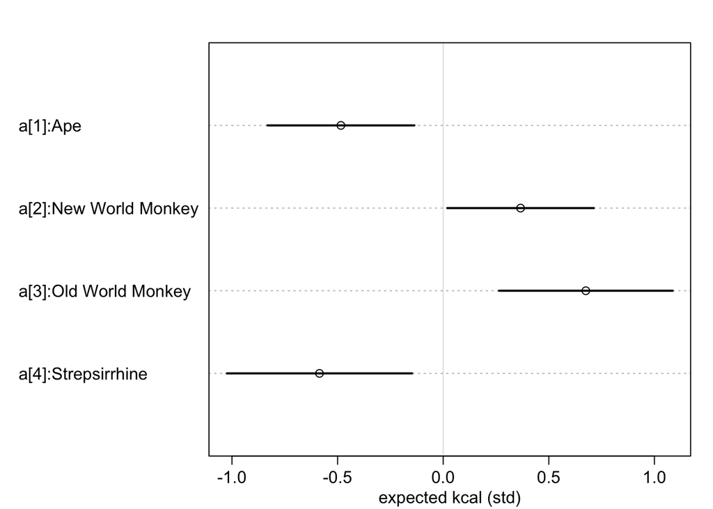

```r
d.m$clade_id <- as.integer( d.m$clade)
d.m$K <- standardize( d.m$kcal.per.g)

m5.9 <- quap(
  alist(
    K ~ dnorm( mu, sigma),
    mu <- a[clade_id],
    a[clade_id] ~ dnorm( 0, 0.5),
    sigma ~ dexp( 1)
    ),
  data=d.m
  )

labels = paste( "a[", 1:4,"]:", levels(d.m$clade), sep="")
plot( precis( m5.9, depth=2, pars="a"), labels=labels,
      xlab="expected kcal (std)")
```